# ALP301: COVID multiple hypothesis testing tutorial

April 2020

## Learning Objective

In this tutorial, you will learn about methods for designing and analyzing experiments with multiple treatment conditions.

### Load required packages

```r
# Ensure that pacman is installed for package management and loading.
if (!require("pacman")) install.packages("pacman")
pacman::p_load(tidyverse)
pacman::p_load(randomizr)
pacman::p_load(estimatr)
pacman::p_load(kableExtra)
pacman::p_load(ggthemes)
pacman::p_load(reshape2)
```

### Notation

We will use the same notation and definitions defined in the Experiments tutorial. Here, however, we will make some adjustments for an experiment with multiple treatments.

Again, we’ll consider a hypothetical data set with $N$ observations. Each observation in our data set is indexed by $i$, and is represented by:

- $W_{i} \in \{1, \dots, K\}$: a variable indicating which of $K$ treatment arms an individual was assigned
- $Y_{i}^{obs} \in \mathbb{R}$: a real-valued variable indicating the observed outcome for that individual

We make use of the *potential outcomes* framework of Rubin (1974), and define the following random variables:

- $Y_{i}(1)$: the outcome unit $i$ would attain if they received treatment 1
- $Y_{i}(2)$: the outcome unit $i$ would attain if they received treatment 2
- $\dots$
- $Y_{i}(K)$: the outcome unit $i$ would attain if they received treatment K

This results in a table of potential outcomes as produced below, where black values ($Y_{i}(k)$) are the ones we observe, and grayed-out values ($Y_{i}(k)$) are the ones we don’t observe.

| $i$ | $W_i$ | $Y_{i}(1)$ | $Y_{i}(2)$ | $\cdots$ | $Y_{i}(K)$ |
| --- | --- | --- | --- | --- | --- |
| 1 | 2 | $Y_{1}(1)$ | $Y_{1}(2)$ | $\cdots$ | $Y_{1}(K)$ |
| 2 | K | $Y_{2}(1)$ | $Y_{2}(2)$ | $\cdots$ | $Y_{2}(K)$ |
| $\cdots$ | $\cdots$ | $\cdots$ | $\cdots$ | $\cdots$ | $\cdots$ |
| N | 1 | $Y_{N}(1)$ | $Y_{N}(2)$ | $\cdots$ | $Y_{N}(K)$ |

Using the potential outcome notation above, the observed outcome can also be written as

$$Y_{i}^{obs} = \sum_{w = 1}^K 1\{W_{i} = w\} \times Y_{i}(w)$$

We denote $Y_{i}^{obs}$ simply as $Y_{i}$ from now on.

## Multiple Hypotheses

Suppose we are running an experiment with a control condition, where $W = 0$ and three treatment interventions, where $W = 1, 2, 3$, for a total of four conditions.

We might like to then measure three treatment effects, as the difference between each expected potential outcomes under each treatment condition and the control condition.
$$\tau_1 = \textrm{E}[Y(1)-Y(0)]\\
\tau_2 = \textrm{E}[Y(2)-Y(0)]\\
\tau_2 = \textrm{E}[Y(3)-Y(0)]$$
Let’s suppose that outcomes under each condition are normally distributed, with mean 0 and standard deviation 1 (note that this means that all average treatment effects are 0). We’ll start with an experiment size of 1000, with treatment randomly assigned.

```r
N <- 1000 # experiment size
K <- 4 # number of experimental conditions

mean_vals <- rep(0, K) # true means
# outcome matrix
ymat <- mapply(rnorm, n = N, mean = mean_vals)

# complete random assignment; ensure each condition gets balanced assignment
w <- complete_ra(N, m_each = rep(N/4, 4))
levels(w) <- 0:3
table(w)
```

```
## w
##   0   1   2   3
## 250 250 250 250
```

```r
# observe outcomes based on treatment assignment
yobs <- ymat[cbind(1:N, as.numeric(w))]
```

And we might then want to test a hypothesis about each of those treatment conditions separately. For example, we might want to test the hypothesis that each treatment effect is greater than zero:
$$H_0: \tau_w = 0 \\
H_A: \tau_w > 0 \\
\text{For each }w = 1, 2, 3$$
We can test each of these hypotheses separately. Recall that when we test a single hypothesis, we calculate a test statistic and reject the null hypothesis $H_0$ if the test statistic is in the relevant rejection region.

The test-statistic Z for each test is:
$$Z = \frac{\hat{\tau}_w}{\sigma \sqrt{2\times K} /\sqrt{N} }$$
To estimate $\tau_w$, we’ll use the difference in means:
$$\hat{\tau}_w = \bar{Y}(w) - \bar{Y}(0)$$

```r
# means under each condition
ybars <- aggregate(yobs, by=list(w), mean)$x
sigma <- sqrt( sum((yobs-ybars[w])^2 )/(N-K))
# difference in means estimates
taus <- ybars[-1]-ybars[1]

# Z-stat
Zs <- taus/(sigma*sqrt(2*K/N))
Zs
```

```
## [1] -2.1061006 -0.2108469 -0.5632525
```

If we set the significance level at 0.05, we would say that our estimate achieves statistical significance if we would observe an estimate that large only 5% of the time under the null distribution. The null distribution is the distribution of the statistic if the null hypothesis were true. Another way of saying this is, if the true treatment effect size is actuallly zero, we will get an estimate this large 1/20 times just by chance!

```r
alpha = 0.05
critical_value = qnorm(1-alpha)
critical_value
```

```
## [1] 1.644854
```

For the one-sided hypothesis above and a significance value of $\alpha = 0.05$, we would reject the null hypothesis for each arm if the test statistic is greater that 1.645–here, it is not, for any of our arms.

```r
Zs>critical_value
```

```
## [1] FALSE FALSE FALSE
```

But if we use standard critical values to determine the rejection region, the chance that *at least one* of our treatment effects is statistically significant just by chance has now increased. Suppose all of our treatment effects are zero: $\tau_1 = \tau_2 = \tau_3 = 0$ and all of the tests are independent. If the probability that we find *at least one* estimate that is statistically distinguishable from zero is now 1-(19/20)^3 = 0.143. That’s pretty high considering we set our significance level at 0.05. And that’s only with three treatment arms! If we keep on increasing the number of treatment effects we’re testing, the probability that we find *at least one* false positive keeps on increasing.

### Bonferroni Correction

An easy way to account for this is to use a Bonferonni correction. In this method, if you are conducting $n$ tests and you want to target a significance level of $\alpha = 0.05$, we use $\alpha/n$ instead. So, as we’re making 3 comparisons here, we would use $0.05/3 = 0.0167$ when calculating our critical value.

```r
alpha = 0.05
n = 3
critical_value = qnorm(1-alpha/n)
critical_value
```

```
## [1] 2.128045
```

Our new critical value of 2.128 is more extreme than the critical value without the correction.

Whereas before our chance of finding at least one false positive under the null was 0.143, now it is 1 - (1 - 0.05/3)^3 $\approx$ 0.05–back to our targeted significance level.

### Power

In the previous Experiments tutorial, we defined power:

Formally, **power is the probability that we will reject the null hypothesis when the alternative hypothesis is true.** I.e.,
$$\textrm{Power}: 1- \beta = \Pr\left( Z \ge z_{\alpha} | H_A \right)$$

where $\beta$ is our probability of Type II error–that we fail to reject the null hypothesis when the alternative is actually true.

**Here we consider power as the probability that we will reject *at least one* of the null hypotheses under the alternative hypotheses that we posed.**

**Aside:** With multiple treatments, we could consider alternative definitions of power, such as the probability that we reject ALL of the null hypotheses. This approach is addressed in Egap’s [Power Analysis Simulations in R](http://egap.org/content/power-analysis-simulations-r), and is included as a secondary output in the function below.

### Example

EGAP (Evidence in Governance and Politics) has simulation code for a number of power calculations [here](http://egap.org/content/power-analysis-simulations-r). We adapt code from one of these examples below.

We will write out a function that does power calculations for one- and two-tailed hypotheses. We will have to input the mean values for each of the treatments and the control, the combined variance, the significance level of our test, the total sample size of the experiment, and the type of hypothesis (‘two.tailed’, ‘greater’, or ‘lower’, where ‘greater’ tests that the treatment has a mean that is greater than the control mean, and ‘lower’ that the treatment has a lower mean).

```r
power_calculator <- function(mus, # treatment means
                             mu_0, # control mean
                             sigma = 1, # standard deviation
                             alpha = 0.05, # significance level
                             N, # experiment size
                             hypothesis = 'two.tailed' # type of hypothesis
){
  n <- length(mus) # number of comparisons
  # The tails of our statistics distributions
  lowertails <- (abs(mus - mu_0)*sqrt(N))/(sigma*sqrt(2*(n+1)))
  uppertails <- -1*lowertails
  if(hypothesis == 'two.tailed'){
    # HA: \mus \neq \mu_0
    pwr_atleastone <- max(pnorm(lowertails - qnorm(1-(alpha/2)/n),
                                lower.tail=TRUE) +
                            1- pnorm(uppertails - qnorm(1-(alpha/2)/n),
                                     lower.tail=FALSE))
    pwr_all <- min(pnorm(lowertails - qnorm(1-(alpha/2)),
                         lower.tail=TRUE) +
                     1- pnorm(uppertails - qnorm(1-(alpha/2)),
                              lower.tail=FALSE))
  } else if(hypothesis == 'greater'){
    # HA: \mus > \mu_0
    pwr_atleastone <- max(pnorm(lowertails - qnorm(1-alpha/n),
                                lower.tail=TRUE))
    pwr_all <- min(pnorm(lowertails - qnorm(1-alpha), lower.tail=TRUE))
  } else if(hypothesis == 'lower'){
    # HA: \mus < \mu_0
    pwr_atleastone <- max(1 - pnorm(uppertails- qnorm(1-alpha/n),
                                    lower.tail=FALSE))
    pwr_all <- min(1 - pnorm(uppertails- qnorm(1-alpha), lower.tail=FALSE))
  }
  return(c(pwr_atleastone, pwr_all))
}
```

The first output of the function is the power for rejecting *at least one* of the null hypotheses. The second output of the function is the power for rejecting *all* of the null hypotheses.

Suppose $\mu_0 = 0$, $\mu_1 = 0.2$, and $\mu_2 = 0.3$, and we want to test the one-sided hypotheses that $\mu_1 > \mu_0$ and $\mu_2 > \mu_0$.

Suppose we ran an experiment with 300 observations.

```r
mus = c(0.2, 0.3)
mu_0 = 0
sigma = 1
hypothesis = 'greater'

pwr <- power_calculator(mus = mus,
                        mu_0 = mu_0,
                        sigma = 1,
                        alpha=0.05,
                        N = 300,
                        hypothesis = hypothesis)
```

Our power for rejecting at least one of the null hypotheses is only 0.564–if we ran this experiment many times, in only 56.4 percent of our experiments would we find an effect so that we could reject one of the null hypotheses.

We can run the function over a range of possible experiment sizes, and find where we get an experiment that has the power that we’re targeting.

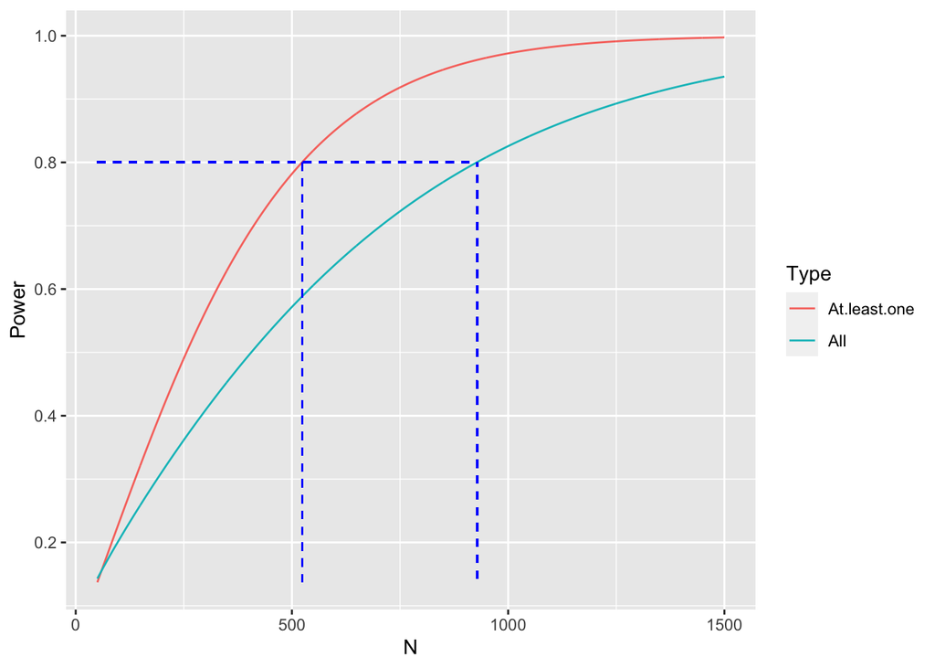

```r
poss.ns <- seq(50, 1500) # potential experiment size

pwr_mat <- sapply(poss.ns, function(n) power_calculator(
  mus = mus,
  mu_0 = mu_0,
  sigma = sigma,
  alpha=0.05,
  N = n,
  hypothesis = hypothesis))

# plot the power
gg_df <- data.frame(N = poss.ns, `At least one` = pwr_mat[1,], All = pwr_mat[2,])

gg_df <- gg_df %>% melt(id.vars = 'N', value.name = 'Power',
                        variable.name = 'Type')
gg_power <- ggplot(gg_df, aes(x = N, y = Power, group = Type, col = Type)) +
  geom_line() +
  geom_segment(aes(x = poss.ns[min(which(pwr_mat[1,]>0.8))],
                   y = min(pwr_mat[1,]),
                   xend = poss.ns[min(which(pwr_mat[1,]>0.8))],
                   yend = pwr_mat[1, min(which(pwr_mat[1,]>0.8))]),
               data = gg_df, colour = 'blue', lty = 'dashed') +
  geom_segment(aes(x = min(poss.ns),
                   y = pwr_mat[1, min(which(pwr_mat[1,]>0.8))],
                   xend = poss.ns[min(which(pwr_mat[1,]>0.8))],
                   yend = pwr_mat[1,min(which(pwr_mat[1,]>0.8))]),
               data = gg_df, colour = 'blue', lty = 'dashed') +
  geom_segment(aes(x = poss.ns[min(which(pwr_mat[2,]>0.8))],
                   y = min(pwr_mat[2,]),
                   xend = poss.ns[min(which(pwr_mat[2,]>0.8))],
                   yend = pwr_mat[2, min(which(pwr_mat[2,]>0.8))]),
               data = gg_df, colour = 'blue', lty = 'dashed') +
  geom_segment(aes(x = min(poss.ns),
                   y = pwr_mat[2, min(which(pwr_mat[2,]>0.8))],
                   xend = poss.ns[min(which(pwr_mat[2,]>0.8))],
                   yend = pwr_mat[2,min(which(pwr_mat[2,]>0.8))]),
               data = gg_df, colour = 'blue', lty = 'dashed') +
  scale_y_continuous(breaks=seq(0.2, 1, .2))

gg_power
```

We find our targeted power, .80, at an experiment size of N = 524.